# Análisis preliminar de variables en la estandarización de un modelo animal de obesidad inducido por dieta

Maripaz Castro-Murillo

# **INTRODUCCIÓN**

#### Los cambios en los estilos de vida de las personas durante los últimos 40 años han llevado a un cambio en la alimentación, que se caracteriza por un aumento en el consumo de alimentos altos en grasa y carbohidratos simples y que poseen una alta palatabilidad, pero también una alta densidad energética. Lo anterior, contribuye con el dramático aumento en los índices de obesidad, tanto en países desarrollados como en vías de desarrollo (Morris *et al.*, 2015). Algunas estimaciones indican que aproximadamente mil millones de personas alrededor del mundo tienen sobrepeso, y 400 millones de estas son obesas (Morris *et al.*, 2015).

#### En Costa Rica la obesidad ha aumentado considerablemente en los últimos años. Según datos de población urbana costarricense, aproximadamente el 63% de las personas entre 15-65 años muestran alteraciones del peso corporal (Fisberg *et al.*, 2016; Kovalskys *et al.*, 2019), y a nivel nacional pero en población escolar, se reportó una prevalencia de 34% de sobrepeso y obesidad (Ministerio de Salud y Ministerio de Educación Pública, 2017).

#### La obesidad es un trastorno metabólico que se caracteriza por una acumulación excesiva de tejido adiposo, además de un índice de masa corporal (IMC) mayor a 30. Su desarrollo involucra una interacción compleja entre la susceptibilidad genética individual y el ambiente en el que se desenvuelven los individuos, caracterizado por una dieta alta en alimentos energéticamente densos, ricos en grasa y azúcar, unido a estilos de vida sedentarios y con altos niveles de estrés que acompañan la vida moderna occidental (Lyon & Hirschhorn, 2005; Popkin & Reardon, 2018).

#### La ganancia de peso puede ser debida a múltiples factores, por ejemplo genéticos, metabólicos o ambientales. Este último factor tiene especial relevancia, pues el aumento en las cifras de obesidad va de la mano con el aumento en jornadas de trabajo, así como situaciones de estrés generadas en las personas desde etapas tempranas (Morris *et al.*, 2015). Las facilidades para obtener alimentos energéticamente densos y de bajo costo han aumentado, incluso algunos estudios reportan que las personas llaman a estos alimentos comida “confort”, en respuesta a su consumo tras situaciones estresantes (Toniyama *et al.*, 2011). El consumo de alimentos palatables puede entonces asociarse con situaciones de estrés, aumentando su consumo.

#### El consumo excesivo de alimentos de alta palatabilidad, o sabrosos, puede resultar en alteraciones de los parámetros biométricos relacionados con el peso corporal, como lo son un aumento en el IMC y un aumento en la grasa corporal (Blumenthal & Gold, 2010). El consumo de los alimentos mencionados pueden inducir cambios neuroplásticos y llevar al individuo a la sobreingesta de estos, debido a una activación del sistema mesocorticolímbico-dopaminérgico (DA), el cual consta de regiones cerebrales como el estriado dorsal (ED) y el núcleo accumbens (Nac) (Berthoud, Lenard & Shin, 2001; Morris et al. 2015).

#### El estudio de la obesidad es complejo, principalmente debido a que es difícil y complicado éticamente estudiar poblaciones humanas. Por este motivo es que se utilizan modelos animales tales como los que describe Kleinert y colaboradores (2018). Generar obesidad en animales de laboratorio permite controlar muchas de las variables que llevan al desarrollo de obesidad, así como de estudiar alteraciones en la conducta, tales como el estrés y la ansiedad. Esto se realiza alimentando a los animales con una dieta de cafetería, una dieta alta en grasas y carbohidratos provenientes de alimentos de consumo humano, con el fin de generar características biométricas que llevan al desarrollo de obesidad: altos valores de glucosa en sangre, altos valores de triglicéridos y colesterol en sangre y un alto porcentaje de grasa en tejido adiposo. Además, el consumo de alimentos de alta palatabilidad puede alterar la expresión de muchos genes, entre ellos los relacionados con procesos de ansiedad en algunas regiones del sistema DA, estos genes son CREB, BDNF y su receptor TrkB. Estas características llevan al individuo al desarrollo del fenotipo obeso, que se manifiesta principalmente por un aumento en el peso.

#### Nuestro proyecto pretende estudiar los efectos del consumo de una dieta de alta palatabilidad sobre cambios que llevan al individuo a la sobreingesta de estos, debido a una activación del sistema mesocorticolímbico-dopaminérgico, y que puede generar alteraciones en genes asociados con estrés y ansiedad. Los datos de este experimento fueron tomados de un piloto que se realizó para verificar que los animales no sufran alteracones gastrointestinales por la dieta, por lo que se aprovecharon los datos para cuestionarnos:

## **PREGUNTA DE INVESTIGACIÓN:**

#### ¿Cuáles son las variables que tendrían un efecto significativo sobre la variable respuesta?, con el fin de saber cuáles no son importantes de considerar en futuros modelos.

#### Este análisis incluye un DAG tipo pipe que relaciona el tipo de dieta (sea dieta de cafetería o control), y las diferentes variables que llevan al individuo a aumentar o disminuir el peso. Los controles consumieron alimento de roedor de laboratorio estándar.

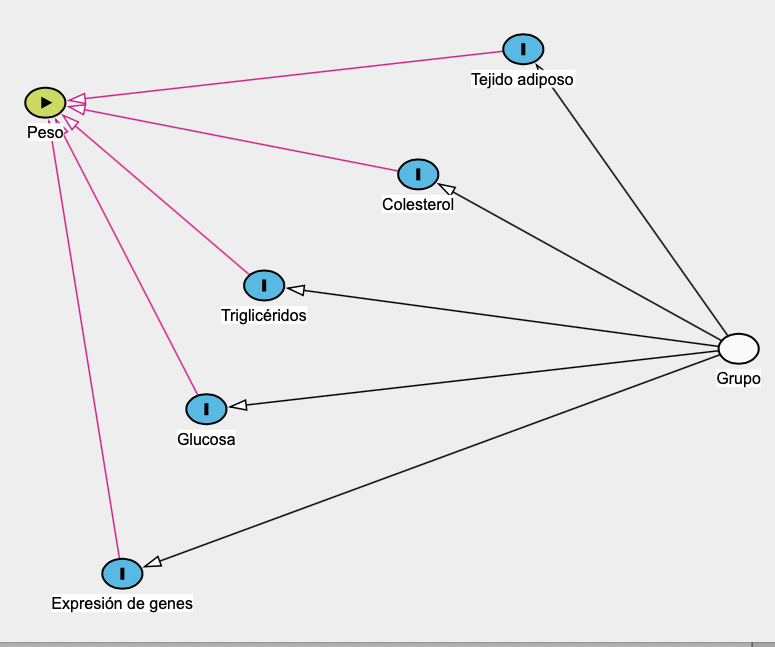

#### La base de datos y todo lo que se necesita para reproducir el análisis se encuentra en el siguiente [Link](https://github.com/maripaz0505/Proyecto_Final_Investigacion_reproducible)

# **METODOLOGÍA Y RESULTADOS**

#### El experimento se realizó en la sala de experimentación animal del Laboratorio de Ensayos Biológicos de la UCR. La exposición a la dieta, o al alimento estándar para el caso de los controles, fue de 90 días. Posterior a la exposición los animales se pesaron y se realizó la eutanasia de los mismos, con el fin de colectar todo el tejido adiposo perogonadal y abdominal (que representa la grasa corporal),y las secciones del cerebro que se querían estudiar. Una vez extraídas las regiones cerebrales se congelaron con el reactivo preservante TRIzol, y se congelaron a -80ºC, con el fin de evitar la degradación de ARN. Además se colectó sangre troncal, para analizar parámetros de bioquímica sanguínea como glucosa,triglicéridos y colesterol total. Para la expresión genética se realizó una qPCR y se analizaron los valores de delta-RT, que son los que aparecen en la base de datos.

#### Cuando se obtuvieron los resultados respectivos y se tabularon los resultados se procedió con el análisis siguiente:

#### Las librerías necesarias son las siguientes:

```r
library(knitr)
library(prettydoc)
library(caTools)
library(ggplot2)
library(car)
library(ggplot2)
library(psych)
library(pscl)
library(MuMIn)
library(lmtest)
library(nlme)
```

#### Cargamos la base de datos con todas las variables, recordando que la variable dependiente es el peso al final de la semana 9 (PESOSEM)

```r
 obesos <- read.csv("Piloto1.csv", header = T, sep = ";")
```

```r
str(obesos)
```

```
## 'data.frame':    16 obs. of  15 variables:
##  $ ANIMAL      : int  1 2 3 4 5 6 7 8 9 10 ...
##  $ GRUPO       : int  2 2 1 1 1 2 2 1 2 1 ...
##  $ PESOSEM9    : int  487 461 407 395 373 479 475 376 406 362 ...
##  $ TADIPOSO.REL: num  7.8 6.8 4.8 5.7 4 9.3 8.4 6.1 9.2 3.9 ...
##  $ GLUC..mg.dL.: int  110 118 107 118 110 110 108 114 150 109 ...
##  $ COL.mg.dL.  : int  51 58 60 79 67 57 60 77 57 57 ...
##  $ TG..mg.dL.  : int  83 82 165 249 135 126 137 194 153 114 ...
##  $ ED.BDNF     : num  0.626 0.262 0.547 0.352 0.109 ...
##  $ ED.TrkB     : num  6.13 3.39 3.27 3.43 12.73 ...
##  $ ED.CRF      : num  0.02 0.048 0.053 0.009 0.212 0.114 0.015 0.078 0.177 0.097 ...
##  $ ED.CREB     : num  0.119 0.257 0.188 0.097 0.105 ...
##  $ Nac.BDNF    : num  0.006 0.006 0.007 0.007 0.051 0.01 0.011 0.026 0.023 0.013 ...
##  $ Nac.TrkB    : num  1.56 2.16 2.01 1.88 2.29 ...
##  $ Nac.CRF     : num  0.1 0.131 0.099 0.134 0.124 0.037 0.113 0.096 0.107 0.068 ...
##  $ Nac.CREB    : num  0.221 0.232 0.207 0.157 0.14 0.278 0.366 0.328 0.172 0.184 ...
```

```r
head(obesos)
```

```
##   ANIMAL GRUPO PESOSEM9 TADIPOSO.REL GLUC..mg.dL. COL.mg.dL. TG..mg.dL. ED.BDNF
## 1      1     2      487          7.8          110         51         83  0.6260
## 2      2     2      461          6.8          118         58         82  0.2620
## 3      3     1      407          4.8          107         60        165  0.5470
## 4      4     1      395          5.7          118         79        249  0.3520
## 5      5     1      373          4.0          110         67        135  0.1091
## 6      6     2      479          9.3          110         57        126  0.5820
##   ED.TrkB ED.CRF ED.CREB Nac.BDNF Nac.TrkB Nac.CRF Nac.CREB
## 1   6.126  0.020  0.1189    0.006    1.558   0.100    0.221
## 2   3.387  0.048  0.2570    0.006    2.158   0.131    0.232
## 3   3.272  0.053  0.1880    0.007    2.014   0.099    0.207
## 4   3.434  0.009  0.0970    0.007    1.879   0.134    0.157
## 5  12.729  0.212  0.1046    0.051    2.289   0.124    0.140
## 6   4.740  0.114  0.0460    0.010    2.938   0.037    0.278
```

#### Primero vamos a evaluar los supuestos de toda la base:

# **NORMALIDAD**

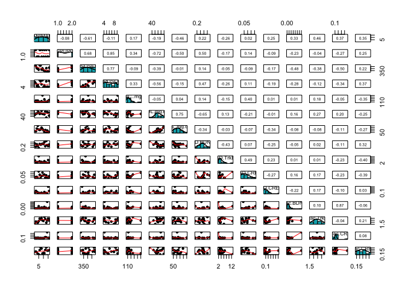

```r
pairs.panels(obesos,
             method = "pearson", # correlation method
             hist.col = "#00AFBB",
             density = TRUE,  # show density plots
             ellipses = F # show correlation ellipses
)
```

# **MULTICOLINEALIDAD**

```
##  [1] "ANIMAL"       "GRUPO"        "PESOSEM9"     "TADIPOSO.REL" "GLUC..mg.dL."
##  [6] "COL.mg.dL."   "TG..mg.dL."   "ED.BDNF"      "ED.TrkB"      "ED.CRF"
## [11] "ED.CREB"      "Nac.BDNF"     "Nac.TrkB"     "Nac.CRF"      "Nac.CREB"
```

```
##                   ANIMAL       GRUPO    PESOSEM9 TADIPOSO.REL GLUC..mg.dL.
## ANIMAL        1.00000000 -0.08134892 -0.60829695   -0.1129038   0.16964018
## GRUPO        -0.08134892  1.00000000  0.68462151    0.8528029   0.33733445
## PESOSEM9     -0.60829695  0.68462151  1.00000000    0.7720568  -0.09430040
## TADIPOSO.REL -0.11290375  0.85280287  0.77205679    1.0000000   0.33075483
## GLUC..mg.dL.  0.16964018  0.33733445 -0.09430040    0.3307548   1.00000000
## COL.mg.dL.   -0.18800405 -0.72266602 -0.39351108   -0.5604138  -0.05422150
## TG..mg.dL.   -0.45869450 -0.50328052 -0.01040580   -0.1545795   0.03551246
## ED.BDNF       0.21743148  0.50349363  0.14333015    0.4653621   0.14168562
## ED.TrkB      -0.26249648 -0.16851198 -0.04767200   -0.2574299  -0.14983785
## ED.CRF        0.02003953  0.13883978 -0.09414525    0.1088605   0.40120236
## ED.CREB       0.24520890 -0.09094226 -0.17252930   -0.1942334   0.01338311
## Nac.BDNF      0.32614438 -0.22566235 -0.48256835   -0.2832984   0.01016165
## Nac.TrkB      0.45812624 -0.03506217 -0.37848299   -0.1198740   0.18497565
## Nac.CRF       0.37194317 -0.26959140 -0.49960256   -0.3410479  -0.04931203
## Nac.CREB      0.34998647  0.24888988  0.21760975    0.3747926  -0.34989655
##                COL.mg.dL.  TG..mg.dL.     ED.BDNF      ED.TrkB      ED.CRF
## ANIMAL       -0.188004053 -0.45869450  0.21743148 -0.262496481  0.02003953
## GRUPO        -0.722666015 -0.50328052  0.50349363 -0.168511984  0.13883978
## PESOSEM9     -0.393511085 -0.01040580  0.14333015 -0.047672003 -0.09414525
## TADIPOSO.REL -0.560413812 -0.15457946  0.46536209 -0.257429889  0.10886053
## GLUC..mg.dL. -0.054221502  0.03551246  0.14168562 -0.149837850  0.40120236
## COL.mg.dL.    1.000000000  0.75433581 -0.65376772  0.126199094 -0.21421902
## TG..mg.dL.    0.754335806  1.00000000 -0.34230634 -0.031209847 -0.07129925
## ED.BDNF      -0.653767724 -0.34230634  1.00000000 -0.426294663  0.06954052
## ED.TrkB       0.126199094 -0.03120985 -0.42629466  1.000000000  0.49283407
## ED.CRF       -0.214219019 -0.07129925  0.06954052  0.492834066  1.00000000
## ED.CREB      -0.009184805 -0.33784034 -0.25339001  0.229777242 -0.26578145
## Nac.BDNF      0.161820919 -0.08088686 -0.04677973  0.005218623  0.16206930
## Nac.TrkB      0.265648944 -0.07596096  0.02003901  0.009812317  0.17355304
## Nac.CRF       0.199685643 -0.10598327 -0.10743905 -0.233238536 -0.22654306
## Nac.CREB     -0.254176576 -0.26807734  0.32398412 -0.402276346 -0.39306274
##                   ED.CREB     Nac.BDNF     Nac.TrkB     Nac.CRF    Nac.CREB
## ANIMAL        0.245208900  0.326144383  0.458126239  0.37194317  0.34998647
## GRUPO        -0.090942259 -0.225662353 -0.035062170 -0.26959140  0.24888988
## PESOSEM9     -0.172529302 -0.482568355 -0.378482990 -0.49960256  0.21760975
## TADIPOSO.REL -0.194233362 -0.283298355 -0.119874037 -0.34104788  0.37479257
## GLUC..mg.dL.  0.013383114  0.010161654  0.184975651 -0.04931203 -0.34989655
## COL.mg.dL.   -0.009184805  0.161820919  0.265648944  0.19968564 -0.25417658
## TG..mg.dL.   -0.337840340 -0.080886863 -0.075960956 -0.10598327 -0.26807734
## ED.BDNF      -0.253390008 -0.046779734  0.020039005 -0.10743905  0.32398412
## ED.TrkB       0.229777242  0.005218623  0.009812317 -0.23323854 -0.40227635
## ED.CRF       -0.265781452  0.162069304  0.173553045 -0.22654306 -0.39306274
## ED.CREB       1.000000000 -0.221817292  0.174539051 -0.10355908  0.02664282
## Nac.BDNF     -0.221817292  1.000000000  0.101452344  0.87499664 -0.06004882
## Nac.TrkB      0.174539051  0.101452344  1.000000000 -0.04064073  0.20504115
## Nac.CRF      -0.103559084  0.874996642 -0.040640733  1.00000000  0.08403833
## Nac.CREB      0.026642820 -0.060048822  0.205041147  0.08403833  1.00000000
```

```
##        GRUPO TADIPOSO.REL   COL.mg.dL. GLUC..mg.dL.   TG..mg.dL.      ED.BDNF
##    13.104194    16.446929    16.105745     2.920011    14.965090     3.506339
##      ED.TrkB      ED.CREB     Nac.CREB     Nac.BDNF     Nac.TrkB
##     1.903612     2.141602     4.750551     1.762895     2.388638
```

# **RESIDUALES**

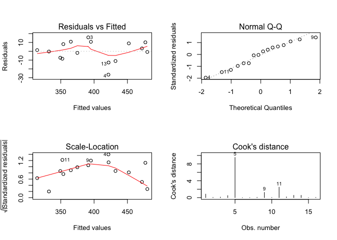

```r
obesos$GRUPO <- as.factor(obesos$GRUPO)
obesos.lm <- lm(PESOSEM9 ~ GRUPO + TADIPOSO.REL + COL.mg.dL.+ GLUC..mg.dL. +                     TG..mg.dL. + ED.BDNF + ED.TrkB + ED.CREB + Nac.CREB +
                    Nac.BDNF + Nac.TrkB, data = obesos)

par(mfrow = c(2, 2), oma = c(0, 0, 0, 0))
plot(obesos.lm, ask = F, which = 1:4)
```

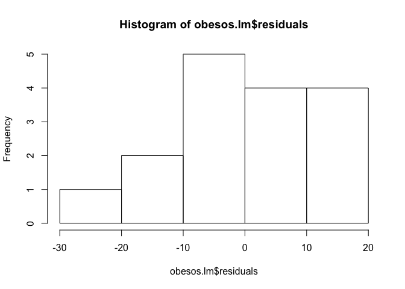

```r
par(mfrow = c(1, 1), oma = c(0, 0, 0, 0))
hist(obesos.lm$residuals)
```

```r
shapiro.test(obesos.lm$residuals)
```

```
##
##  Shapiro-Wilk normality test
##
## data:  obesos.lm$residuals
## W = 0.94258, p-value = 0.3818
```

#### Conclusión: El gráfico Q-Q e histograma muestra que los residuales no desvián de una distribución normal. La prueba SW tampoco muestra que no hay evidencia de que los residuos no sigan una distribución normal. Entonces las pruebas de hipótesis son confiables.

# **SELECCIÓN DEL MODELO**

#### Selección automatizada:

```r
options(na.action = "na.fail")
m <- dredge(obesos.lm, rank="AIC")
```

```
## Fixed term is "(Intercept)"
```

```r
m0 <- lm(PESOSEM9 ~ 1, data = obesos)
summary(m0)
```

```
##
## Call:
## lm(formula = PESOSEM9 ~ 1, data = obesos)
##
## Residuals:
##     Min      1Q  Median      3Q     Max
## -83.062 -41.562   1.438  31.938  87.937
##
## Coefficients:
##             Estimate Std. Error t value Pr(>|t|)
## (Intercept)   399.06      13.65   29.24 1.21e-14 ***
## ---
## Signif. codes:  0 '***' 0.001 '**' 0.01 '*' 0.05 '.' 0.1 ' ' 1
##
## Residual standard error: 54.59 on 15 degrees of freedom
```

```r
m.n <- lm(PESOSEM9 ~ GLUC..mg.dL. + GRUPO + Nac.BDNF + Nac.TrkB + TADIPOSO.REL + Nac.CREB, data = obesos)
summary(m.n)
```

```
##
## Call:
## lm(formula = PESOSEM9 ~ GLUC..mg.dL. + GRUPO + Nac.BDNF + Nac.TrkB +
##     TADIPOSO.REL + Nac.CREB, data = obesos)
##
## Residuals:
##     Min      1Q  Median      3Q     Max
## -39.306  -9.932   0.630   8.017  36.922
##
## Coefficients:
##               Estimate Std. Error t value Pr(>|t|)
## (Intercept)   658.3291    92.9815   7.080 5.79e-05 ***
## GLUC..mg.dL.   -2.7663     0.8435  -3.279  0.00954 **
## GRUPO2         15.9038    23.2597   0.684  0.51135
## Nac.BDNF     -337.2361   193.1330  -1.746  0.11474
## Nac.TrkB       -9.1844    15.3736  -0.597  0.56496
## TADIPOSO.REL   23.2216     7.0442   3.297  0.00928 **
## Nac.CREB     -257.7528   131.6128  -1.958  0.08185 .
## ---
## Signif. codes:  0 '***' 0.001 '**' 0.01 '*' 0.05 '.' 0.1 ' ' 1
##
## Residual standard error: 23.6 on 9 degrees of freedom
## Multiple R-squared:  0.8879, Adjusted R-squared:  0.8131
## F-statistic: 11.88 on 6 and 9 DF,  p-value: 0.000781
```

```r
m.n1 <- lm(PESOSEM9 ~ GLUC..mg.dL., data = obesos)
summary(m.n1)
```

```
##
## Call:
## lm(formula = PESOSEM9 ~ GLUC..mg.dL., data = obesos)
##
## Residuals:
##     Min      1Q  Median      3Q     Max
## -84.866 -42.755   0.378  34.169  85.155
##
## Coefficients:
##              Estimate Std. Error t value Pr(>|t|)
## (Intercept)  455.6507   160.2829   2.843    0.013 *
## GLUC..mg.dL.  -0.4891     1.3801  -0.354    0.728
## ---
## Signif. codes:  0 '***' 0.001 '**' 0.01 '*' 0.05 '.' 0.1 ' ' 1
##
## Residual standard error: 56.26 on 14 degrees of freedom
## Multiple R-squared:  0.008893,   Adjusted R-squared:  -0.0619
## F-statistic: 0.1256 on 1 and 14 DF,  p-value: 0.7283
```

```r
m.n2 <- lm(PESOSEM9 ~ GLUC..mg.dL. + GRUPO, data = obesos)
summary(m.n2)
```

```
##
## Call:
## lm(formula = PESOSEM9 ~ GLUC..mg.dL. + GRUPO, data = obesos)
##
## Residuals:
##    Min     1Q Median     3Q    Max
## -78.16 -21.95  11.15  27.17  43.07
##
## Coefficients:
##              Estimate Std. Error t value Pr(>|t|)
## (Intercept)  576.5684   110.8999   5.199 0.000171 ***
## GLUC..mg.dL.  -1.9037     0.9808  -1.941 0.074264 .
## GRUPO2        85.4631    19.9898   4.275 0.000904 ***
## ---
## Signif. codes:  0 '***' 0.001 '**' 0.01 '*' 0.05 '.' 0.1 ' ' 1
##
## Residual standard error: 37.64 on 13 degrees of freedom
## Multiple R-squared:  0.5881, Adjusted R-squared:  0.5247
## F-statistic:  9.28 on 2 and 13 DF,  p-value: 0.003136
```

```r
m.n3 <- lm(PESOSEM9 ~ GLUC..mg.dL. + GRUPO + Nac.BDNF, data = obesos)
summary(m.n3)
```

```
##
## Call:
## lm(formula = PESOSEM9 ~ GLUC..mg.dL. + GRUPO + Nac.BDNF, data = obesos)
##
## Residuals:
##    Min     1Q Median     3Q    Max
## -67.76 -21.16  14.91  22.98  30.37
##
## Coefficients:
##               Estimate Std. Error t value Pr(>|t|)
## (Intercept)   574.7670   101.5069   5.662 0.000105 ***
## GLUC..mg.dL.   -1.7446     0.9017  -1.935 0.076946 .
## GRUPO2         76.8520    18.8630   4.074 0.001542 **
## Nac.BDNF     -513.9852   274.0081  -1.876 0.085212 .
## ---
## Signif. codes:  0 '***' 0.001 '**' 0.01 '*' 0.05 '.' 0.1 ' ' 1
##
## Residual standard error: 34.45 on 12 degrees of freedom
## Multiple R-squared:  0.6815, Adjusted R-squared:  0.6018
## F-statistic: 8.558 on 3 and 12 DF,  p-value: 0.002611
```

```r
m.n4 <- lm(PESOSEM9 ~ GLUC..mg.dL. + GRUPO + Nac.BDNF + Nac.TrkB, data = obesos)
summary(m.n4)
```

```
##
## Call:
## lm(formula = PESOSEM9 ~ GLUC..mg.dL. + GRUPO + Nac.BDNF + Nac.TrkB,
##     data = obesos)
##
## Residuals:
##     Min      1Q  Median      3Q     Max
## -55.465 -19.405   8.687  13.111  43.294
##
## Coefficients:
##               Estimate Std. Error t value Pr(>|t|)
## (Intercept)   615.7902    96.3720   6.390 5.15e-05 ***
## GLUC..mg.dL.   -1.4414     0.8484  -1.699  0.11742
## GRUPO2         74.2711    17.4439   4.258  0.00135 **
## Nac.BDNF     -478.8175   253.2874  -1.890  0.08532 .
## Nac.TrkB      -30.9786    17.5082  -1.769  0.10451
## ---
## Signif. codes:  0 '***' 0.001 '**' 0.01 '*' 0.05 '.' 0.1 ' ' 1
##
## Residual standard error: 31.74 on 11 degrees of freedom
## Multiple R-squared:  0.752,  Adjusted R-squared:  0.6619
## F-statistic: 8.341 on 4 and 11 DF,  p-value: 0.002397
```

```r
m.n5 <- lm(PESOSEM9 ~ GLUC..mg.dL. + GRUPO + Nac.BDNF + Nac.TrkB + TADIPOSO.REL, data = obesos)
summary(m.n5)
```

```
##
## Call:
## lm(formula = PESOSEM9 ~ GLUC..mg.dL. + GRUPO + Nac.BDNF + Nac.TrkB +
##     TADIPOSO.REL, data = obesos)
##
## Residuals:
##     Min      1Q  Median      3Q     Max
## -60.559  -9.933   2.631  15.105  31.975
##
## Coefficients:
##               Estimate Std. Error t value Pr(>|t|)
## (Intercept)   552.1587    85.5841   6.452 7.33e-05 ***
## GLUC..mg.dL.   -1.6842     0.7221  -2.332   0.0419 *
## GRUPO2         24.1948    25.9116   0.934   0.3724
## Nac.BDNF     -388.8125   216.7632  -1.794   0.1031
## Nac.TrkB      -24.4697    15.0057  -1.631   0.1340
## TADIPOSO.REL   15.6690     6.6783   2.346   0.0409 *
## ---
## Signif. codes:  0 '***' 0.001 '**' 0.01 '*' 0.05 '.' 0.1 ' ' 1
##
## Residual standard error: 26.74 on 10 degrees of freedom
## Multiple R-squared:  0.8401, Adjusted R-squared:  0.7601
## F-statistic: 10.51 on 5 and 10 DF,  p-value: 0.0009903
```

```r
m.n6 <- lm(PESOSEM9 ~ GLUC..mg.dL. + GRUPO + TADIPOSO.REL, data = obesos)
summary(m.n6)
```

```
##
## Call:
## lm(formula = PESOSEM9 ~ GLUC..mg.dL. + GRUPO + TADIPOSO.REL,
##     data = obesos)
##
## Residuals:
##     Min      1Q  Median      3Q     Max
## -53.352 -17.350   2.485  18.600  47.382
##
## Coefficients:
##              Estimate Std. Error t value Pr(>|t|)
## (Intercept)  505.9529    95.1127   5.320 0.000182 ***
## GLUC..mg.dL.  -2.0938     0.8113  -2.581 0.024056 *
## GRUPO2        18.8065    29.8776   0.629 0.540852
## TADIPOSO.REL  19.9892     7.4755   2.674 0.020262 *
## ---
## Signif. codes:  0 '***' 0.001 '**' 0.01 '*' 0.05 '.' 0.1 ' ' 1
##
## Residual standard error: 31.01 on 12 degrees of freedom
## Multiple R-squared:  0.7419, Adjusted R-squared:  0.6773
## F-statistic:  11.5 on 3 and 12 DF,  p-value: 0.0007653
```

#### Ahora comparamos los AIC de los modelos hechos para elegir el que tenga un AIC menor

```r
AIC(m0, m.n, m.n1, m.n2, m.n3, m.n4, m.n5, m.n6)
```

```
##      df      AIC
## m0    2 176.3693
## m.n   8 153.3604
## m.n1  3 178.2264
## m.n2  4 166.1787
## m.n3  5 164.0645
## m.n4  6 162.0573
## m.n5  7 157.0402
## m.n6  5 160.7003
```

```r
anova(m.n, m.n5, test ="Chi")
```

```
## Analysis of Variance Table
##
## Model 1: PESOSEM9 ~ GLUC..mg.dL. + GRUPO + Nac.BDNF + Nac.TrkB + TADIPOSO.REL +
##     Nac.CREB
## Model 2: PESOSEM9 ~ GLUC..mg.dL. + GRUPO + Nac.BDNF + Nac.TrkB + TADIPOSO.REL
##   Res.Df    RSS Df Sum of Sq Pr(>Chi)
## 1      9 5012.7
## 2     10 7149.0 -1   -2136.2  0.05018 .
## ---
## Signif. codes:  0 '***' 0.001 '**' 0.01 '*' 0.05 '.' 0.1 ' ' 1
```

```r
summary(m.n5)
```

```
##
## Call:
## lm(formula = PESOSEM9 ~ GLUC..mg.dL. + GRUPO + Nac.BDNF + Nac.TrkB +
##     TADIPOSO.REL, data = obesos)
##
## Residuals:
##     Min      1Q  Median      3Q     Max
## -60.559  -9.933   2.631  15.105  31.975
##
## Coefficients:
##               Estimate Std. Error t value Pr(>|t|)
## (Intercept)   552.1587    85.5841   6.452 7.33e-05 ***
## GLUC..mg.dL.   -1.6842     0.7221  -2.332   0.0419 *
## GRUPO2         24.1948    25.9116   0.934   0.3724
## Nac.BDNF     -388.8125   216.7632  -1.794   0.1031
## Nac.TrkB      -24.4697    15.0057  -1.631   0.1340
## TADIPOSO.REL   15.6690     6.6783   2.346   0.0409 *
## ---
## Signif. codes:  0 '***' 0.001 '**' 0.01 '*' 0.05 '.' 0.1 ' ' 1
##
## Residual standard error: 26.74 on 10 degrees of freedom
## Multiple R-squared:  0.8401, Adjusted R-squared:  0.7601
## F-statistic: 10.51 on 5 and 10 DF,  p-value: 0.0009903
```

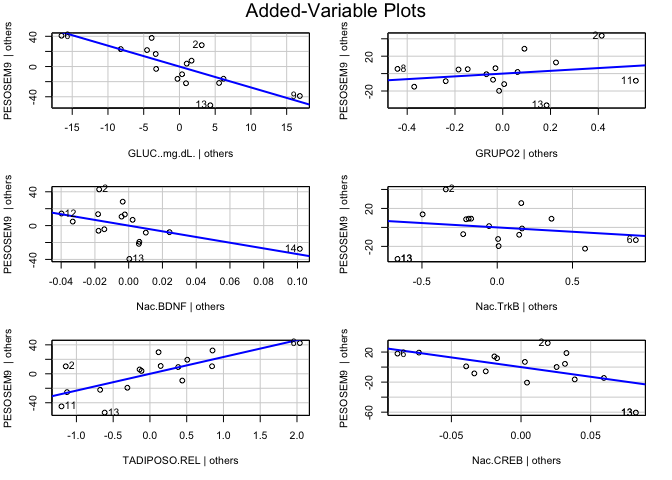

```r
avPlots(m.n, ask=F)
```

#### Con el modelo m.n5 podemos observar que únicamente las variables **tejido adiposo** y **glucosa en sangre** tienen un efecto significativo sobre la variable respuesta.

#### A continuación realizamos gráficos que nos permiten evaluar los residuales de las variables predictoras. Podemos observar las predicciones que se esperarían según el peso del individuo.